# A3: SPL Library Checkouts

### Introduction

The data used in this assignment comes from the [Seattle Public Library](https://data.seattle.gov/Community/Checkouts-by-Title/tmmm-ytt6). This dataset has information about their checkouts which dates as far back as 2005. For this assignment it has been cut off until January of 2023 as the data for February hasn’t been calculated full yet. I’m choosing to analyze the trends of books that have trended on TikTok to see how big of a role social media can play on influencing our society as of recently.

### Summary Information

- Average checkouts: 242.3846
- Month with the least checkouts: January
- Lowest checkouts: 145
- Month with the most checkouts: October
- Most checkouts: 313

### The Dataset

This data was collected by Seattle Public Library and is published on the [Seattle Open Data page](https://data.seattle.gov/Community/Checkouts-by-Title/tmmm-ytt6) by the City of Seattle. This set also has data that goes as far back as 2005 and as recent as January of 2023. In addtion, it is being updated monthly with total number of checkouts for various books, as well as the date that it was checked out on and the medium it was checked out in. This data was collected while keeping each individual’s identity and privacy secure and anonymous. Data that doesn’t do so has a long history of being strictly enforced by companies like BookScan. They go as far as even refusing to sell this data to others doing research. This all goes to show much they care for and want to protect our privacy. The dataset was collected to assist people in aggregating trends and key findings of how book checkouts have changed over time. With key events and movements happening throughout the US, seeing how book checkouts have been influenced by it, can give us lots of great insight on our society.

One ethical concern could be if there is any bias in collecting and the public’s consent to the collection of such data. Prior to this assignment, I had no clue that Seattle Public Library was even collecting such data. This make me question if they have ever asked for consent in collecting such data, as well as is their any bias in the way they are collecting the data.

One limitation of this dataset is that since we have no information on the demographics of the people that are checking out books, it would be very difficult to make larger claims about how events could shift the trends in book checkouts. For example, the Black Lives Matter movement. It wouldn’t be accurate to claim that because of the movement, there was an increase in checkouts of Black authors’ books throughout America. This data was collected from libraries in Seattle which means we should avoid overgeneralizing our findings to other states. Another problem with this dataset is that we have no way of knowing how the library sets up books for people to check out. The Seattle Public Library could be promoting certain books based on the way it’s marketed or positioned in the library which would additionally make our conclusions on book trends inaccurate. Lastly, this dataset most likely isn’t representative of the population as a whole. Some people rely fully on libraries as that is the only resource they can access for information, while others may go to the library occasionally. Due to the inconsistencies, it would be hard again to further expand our findings across a larger group of people.

### Chart 1

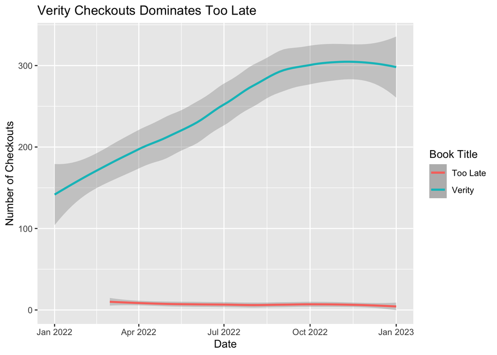

Chart 1 not only reveals the relationship between the number of checkouts for the books Too late and Verity and time, but it also shows us how much of a difference a book being promoted on social media can influence the number of checkouts. Both of these books were written by Colleen Hoover, however as shown in the chart, Verity soars in total number of checkouts in comparison to Too Late. Verity’s peak book checkout was revealed to be 313 in the month of October. This makes me infer that with the increasing popularity of the #booktok trend on tiktok, more people were inclined to checkout Verity. Furthermore, Too Late seems to have a slight decline in terms of checkout with its peak being 11 checkouts in March of 2022.

### Chart 2

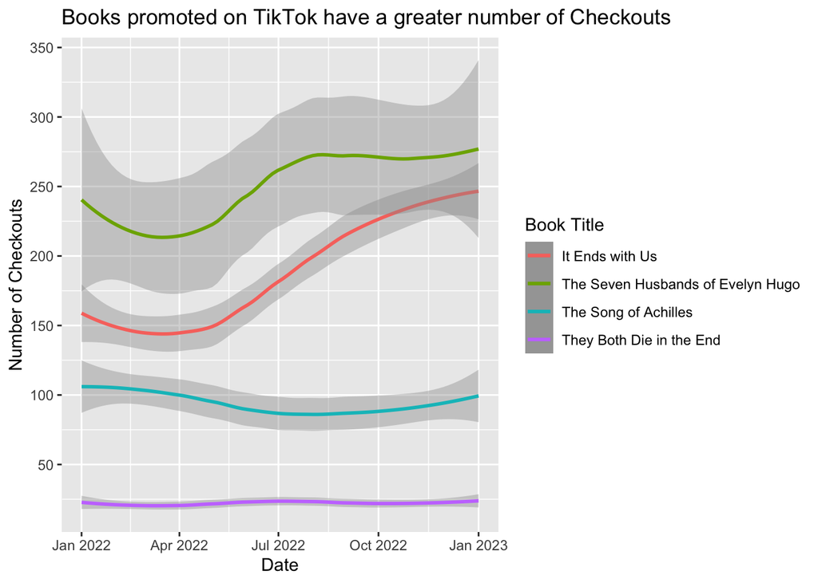

Similarly to the previous chart, chart 2 shows us how social media had some sort of influences over the checkouts of these books. It Ends with Us and The Seven Husbands of Evelyn Hugo were two of the most popular books promoted on social media namely, TikTok. The Song of Achilles and They Both Die in the End on the other hand, weren’t promoted as much in comparison despite being popular books. Looking at the chart, the large increase in checkouts for It Ends with Us and The Seven Husbands of Evelyn Hugo start around may-june of 2022. It Ends with Us had a peak of 247 checkouts and The Seven husbands of Evelyn Hugo had a peak of 335 checkouts. The Song of Achilles and They Both Die in the End however, have a more stagnant trend in checkouts with their peaks being at 135 and 27 checkouts respectively. Moreover, the fact that The Song of Achilles and They Both Die in the End didn’t see an increase around May-June like It Ends with Us and The Seven Husbands of Evelyn Hugo leads me to believe that these books also were promoted by users on TikTok as much.

### Chart 3

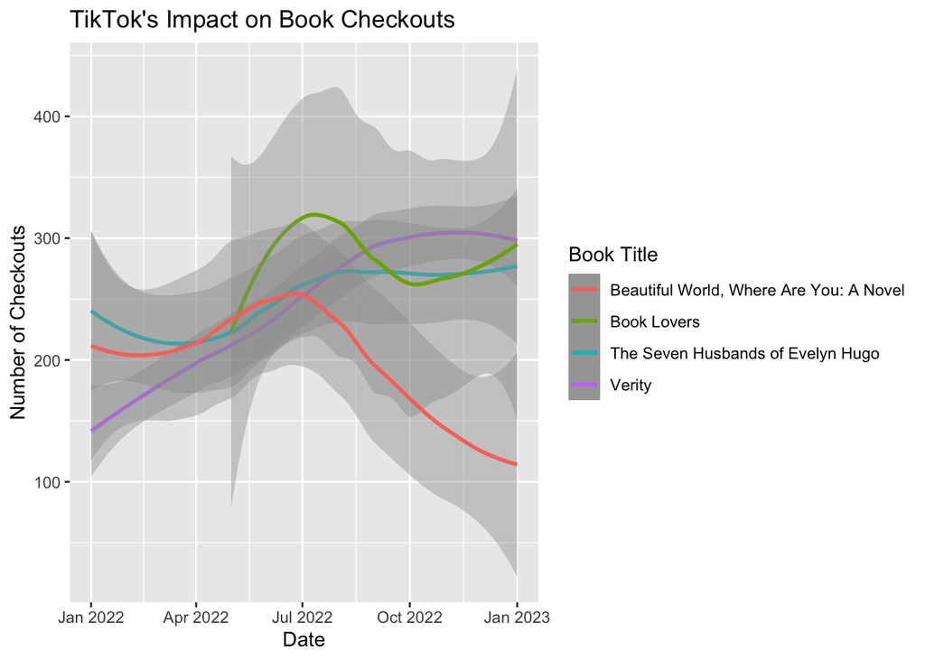